# Pre-process

Elena Eyre, PhD

2022-11-29

# 1. Load libraries of functions and data:

I uploaded data and packages of necessary functions to perform the calculations.

# 2. Load data and extract values to a new table

Load all the WAT sample tables obtained from the pseudo-mapping with salmon:

```r
WAT_HFD_12WK_F_3_S9_salmon <- read_excel("H:/Linux/Vicens/salmon_quants/WAT_HFD_12WK_F_3_S9_quant/WAT_HFD_12WK_F_3_S9_salmon.xlsx")
WAT_HFD_12WK_F_6_S10_salmon <- read_excel("H:/Linux/Vicens/salmon_quants/WAT_HFD_12WK_F_6_S10_quant/WAT_HFD_12WK_F_6_S10_salmon.xlsx")
WAT_HFD_12WK_F_7_S11_salmon <- read_excel("H:/Linux/Vicens/salmon_quants/WAT_HFD_12WK_F_7_S11_quant/WAT_HFD_12WK_F_7_S11_salmon.xlsx")
WAT_RD_12WK_F_5_S12_salmon <- read_excel("H:/Linux/Vicens/salmon_quants/WAT_RD_12WK_F_5_S12_quant/WAT_RD_12WK_F_5_S12_salmon.xlsx")
WAT_RD_12WK_F_7_S13_salmon <- read_excel("H:/Linux/Vicens/salmon_quants/WAT_RD_12WK_F_7_S13_quant/WAT_RD_12WK_F_7_S13_salmon.xlsx")
WAT_RD_12WK_F_8_S14_salmon <- read_excel("H:/Linux/Vicens/salmon_quants/WAT_RD_12WK_F_8_S14_quant/WAT_RD_12WK_F_8_S14_salmon.xlsx")
WAT_HFD_2WK_F_1_S15_salmon <- read_excel("H:/Linux/Vicens/salmon_quants/WAT_HFD_2WK_F_1_S15_quant/WAT_HFD_2WK_F_1_S15_salmon.xlsx")
WAT_HFD_2WK_F_2_S16_salmon <- read_excel("H:/Linux/Vicens/salmon_quants/WAT_HFD_2WK_F_2_S16_quant/WAT_HFD_2WK_F_2_S16_salmon.xlsx")
WAT_HFD_2WK_F_5_S1_salmon <- read_excel("H:/Linux/Vicens/salmon_quants/WAT_HFD__2WK_F_5_S1_quant/WAT_HFD_2WK_F_5_S1_salmon.xlsx")
WAT_RD_2WK_F_1_S2_salmon <- read_excel("H:/Linux/Vicens/salmon_quants/WAT_RD_2WK_F_1_S2_quant/WAT_RD_2WK_F_1_S2_salmon.xlsx")
WAT_RD_2WK_F_2_S3_salmon <- read_excel("H:/Linux/Vicens/salmon_quants/WAT_RD_2WK_F_2_S3_quant/WAT_RD_2WK_F_2_S3_salmon.xlsx")
WAT_RD_2WK_F_4_S4_salmon <- read_excel("H:/Linux/Vicens/salmon_quants/WAT_RD_2WK_F_4_S4_quant/WAT_RD_2WK_F_4_S4_salmon.xlsx")
WAT_HFD_12WK_M_2_S5_salmon <- read_excel("H:/Linux/Vicens/salmon_quants/WAT_HFD__12WK_M_2_S5_quant/WAT_HFD_12WK_M_2_S5_salmon.xlsx")
WAT_HFD_12WK_M_3_S6_salmon <- read_excel("H:/Linux/Vicens/salmon_quants/WAT_HFD__12WK_M_3_S6_quant/WAT_HFD_12WK_M_3_S6_salmon.xlsx")
WAT_HFD_12WK_M_4_S7_salmon <- read_excel("H:/Linux/Vicens/salmon_quants/WAT_HFD__12WK_M_4_S7_quant/WAT_HFD_12WK_M_4_S7_salmon.xlsx")
WAT_RD_12WK_M_2_S8_salmon <- read_excel("H:/Linux/Vicens/salmon_quants/WAT_RD_12WK_M_2_S8_quant/WAT_RD_12WK_M_2_S8_salmon.xlsx")
WAT_RD_12WK_M_3_S9_salmon <- read_excel("H:/Linux/Vicens/salmon_quants/WAT_RD_12WK_M_3_S9_quant/WAT_RD_12WK_M_3_S9_salmon.xlsx")
WAT_RD_12WK_M_4_S10_salmon <- read_excel("H:/Linux/Vicens/salmon_quants/WAT_RD_12WK_M_4_S10_quant/WAT_RD_12WK_M_4_S10_salmon.xlsx")
WAT_HFD_2WK_M_12_S11_salmon <- read_excel("H:/Linux/Vicens/salmon_quants/WAT_HFD__2WK_M_12_S11_quant/WAT_HFD_2WK_M12_S11_salmon.xlsx")
WAT_HFD_2WK_M_13_S12_salmon <- read_excel("H:/Linux/Vicens/salmon_quants/WAT_HFD__2WK_M_13_S12_quant/WAT_HFD_2WK_M_13_S12_salmon.xlsx")
WAT_HFD_2WK_M_14_S13_salmon <- read_excel("H:/Linux/Vicens/salmon_quants/WAT_HFD__2WK_M_14_S13_quant/WAT_HFD_2WK_M_14_S13_salmon.xlsx")
WAT_RD_2WK_M_6_S14_salmon <- read_excel("H:/Linux/Vicens/salmon_quants/WAT_RD_2WK_M_6_S14_quant/WAT_RD_2WK_M_6_S14_salmon.xlsx")
WAT_RD_2WK_M_7_S15_salmon <- read_excel("H:/Linux/Vicens/salmon_quants/WAT_RD_2WK_M_7_S15_quant/WAT_RD_2WK_M_7_S15_salmon.xlsx")
WAT_RD_2WK_M_8_S16_salmon <- read_excel("H:/Linux/Vicens/salmon_quants/WAT_RD_2WK_M_8_S16_quant/WAT_RD_2WK_M_8_S16_salmon.xlsx")
```

Load the data information (metadata):

```r
Samples_code_HFD_MF_2_12wk <- read_excel("H:/Linux/Vicens/Samples_code_HFD_MF_2_12wk.xlsx")
```

# 3. Prepare working tables

Salmon’s output consisted in several variables (https://salmon.readthedocs.io/en/latest/file_formats.html):

- Name — This is the name of the target transcript provided in the input transcript database (FASTA file).
- Length — This is the length of the target transcript in nucleotides.
- EffectiveLength — This is the computed effective length of the target transcript. It takes into account all factors being modeled that will effect the probability of sampling fragments from this transcript, including the fragment length distribution and sequence-specific and gc-fragment bias (if they are being modeled).
- TPM — This is salmon’s estimate of the relative abundance of this transcript in units of Transcripts Per Million (TPM). TPM is the recommended relative abundance measure to use for downstream analysis.
- NumReads — This is salmon’s estimate of the number of reads mapping to each transcript that was quantified. It is an “estimate” insofar as it is the expected number of reads that have originated from each transcript given the structure of the uniquely mapping and multi-mapping reads and the relative abundance estimates for each transcript.

I agreed with Vicent to work by now with TPMs. Thus, I collect the columns of gene names and TPMs to generate a working table:

```r
h12f3s9 <- WAT_HFD_12WK_F_3_S9_salmon[,c(1,4)]
h12f6s10 <- WAT_HFD_12WK_F_6_S10_salmon[,c(1,4)]
h12f7s11 <- WAT_HFD_12WK_F_7_S11_salmon[,c(1,4)]
rd12f5s12 <- WAT_RD_12WK_F_5_S12_salmon[,c(1,4)]
rd12f7s13 <- WAT_RD_12WK_F_7_S13_salmon[,c(1,4)]
rd12f8s14 <- WAT_RD_12WK_F_8_S14_salmon[,c(1,4)]
h2f1s15 <- WAT_HFD_2WK_F_1_S15_salmon[,c(1,4)]
h2f2s16 <- WAT_HFD_2WK_F_2_S16_salmon[,c(1,4)]
h2f5s1 <- WAT_HFD_2WK_F_5_S1_salmon[,c(1,4)]
rd2f1s2 <- WAT_RD_2WK_F_1_S2_salmon[,c(1,4)]
rd2f2s3 <- WAT_RD_2WK_F_2_S3_salmon[,c(1,4)]
rd2f4s4 <- WAT_RD_2WK_F_4_S4_salmon[,c(1,4)]
h12m2s5 <- WAT_HFD_12WK_M_2_S5_salmon[,c(1,4)]
h12m3s6 <- WAT_HFD_12WK_M_3_S6_salmon[,c(1,4)]
h12m4s7 <- WAT_HFD_12WK_M_4_S7_salmon[,c(1,4)]
rd12m2s8 <- WAT_RD_12WK_M_2_S8_salmon[,c(1,4)]
rd12m3s9 <- WAT_RD_12WK_M_3_S9_salmon[,c(1,4)]
rd12m4s10 <- WAT_RD_12WK_M_4_S10_salmon[,c(1,4)]
h2m12s11 <- WAT_HFD_2WK_M_12_S11_salmon[,c(1,4)]
h2m13s12 <- WAT_HFD_2WK_M_13_S12_salmon[,c(1,4)]
h2m14s13 <- WAT_HFD_2WK_M_14_S13_salmon[,c(1,4)]
rd2m6s14 <- WAT_RD_2WK_M_6_S14_salmon[,c(1,4)]
rd2m7s15 <- WAT_RD_2WK_M_7_S15_salmon[,c(1,4)]
rd2m8s16 <- WAT_RD_2WK_M_8_S16_salmon[,c(1,4)]
```

I filtrate the metadata to obtain the wat samples, and discard the file name columns:

```r
metadata <- Samples_code_HFD_MF_2_12wk[Samples_code_HFD_MF_2_12wk$Tissue == "WAT",1:11]
rownames(metadata) <- metadata$`Short code`
```

In order to get an association between the metadata table and the TPMs table, I name the TPMs column with the “Short code” name before joining the TPMs tables according to the gene’s name column:

```r
colnames(h12f3s9)[2] <- 'W_12_F_H_3'
colnames(h12f6s10)[2] <- 'W_12_F_H_6'
colnames(h12f7s11)[2] <- 'W_12_F_H_7'
colnames(rd12f5s12)[2] <- 'W_12_F_RD_5'
colnames(rd12f7s13)[2] <- 'W_12_F_RD_7'
colnames(rd12f8s14)[2] <- 'W_12_F_RD_8'
colnames(h2f1s15)[2] <- 'W_02_F_H_1'
colnames(h2f2s16)[2] <- 'W_02_F_H_2'
colnames(h2f5s1)[2] <- 'W_02_F_H_5'
colnames(rd2f1s2)[2] <- 'W_02_F_RD_1'
colnames(rd2f2s3)[2] <- 'W_02_F_RD_2'
colnames(rd2f4s4)[2] <- 'W_02_F_RD_4'
colnames(h12m2s5)[2] <- 'W_12_M_H_2'
colnames(h12m3s6)[2] <- 'W_12_M_H_3'
colnames(h12m4s7)[2] <- 'W_12_M_H_4'
colnames(rd12m2s8)[2] <- 'W_12_M_RD_2'
colnames(rd12m3s9)[2] <- 'W_12_M_RD_3'
colnames(rd12m4s10)[2] <- 'W_12_M_RD_4'
colnames(h2m12s11)[2] <-'W_02_M_H_12'
colnames(h2m13s12)[2] <- 'W_02_M_H_13'
colnames(h2m14s13)[2] <- 'W_02_M_H_14'
colnames(rd2m6s14)[2] <- 'W_02_M_RD_6'
colnames(rd2m7s15)[2] <- 'W_02_M_RD_7'
colnames(rd2m8s16)[2] <- 'W_02_M_RD_8'
```

At this point, I can join the different TMP tables by the “Name” column. This way, all the counts will be in the same row of the corresponding transcript.

```r
df1 <- left_join(h12f3s9,h12f6s10, by = "Name")
df2 <- left_join(df1,h12f7s11, by = "Name")
df3 <- left_join(df2,rd12f5s12, by = "Name")
df4 <- left_join(df3, rd12f7s13, by = "Name")
df5 <- left_join(df4, rd12f8s14, by = "Name")
df6 <- left_join(df5, h2f1s15, by = "Name")
df7 <- left_join(df6, h2f2s16, by = "Name")
df8 <- left_join(df7, h2f5s1, by = "Name")
df9 <- left_join(df8, rd2f1s2, by = "Name")
df10 <- left_join(df9, rd2f2s3, by = "Name")
df11 <- left_join(df10, rd2f4s4, by = "Name")
df12 <- left_join(df11, h12m2s5, by = "Name")
df13 <- left_join(df12, h12m3s6, by = "Name")
df14 <- left_join(df13, h12m4s7, by = "Name")
df15 <- left_join(df14, rd12m2s8, by = "Name")
df16 <- left_join(df15, rd12m3s9, by = "Name")
df17 <- left_join(df16, rd12m4s10, by = "Name")
df18 <- left_join(df17, h2m12s11, by = "Name")
df19 <- left_join(df18, h2m13s12, by = "Name")
df20 <- left_join(df19, h2m14s13, by = "Name")
df21 <- left_join(df20, rd2m6s14, by = "Name")
df22 <- left_join(df21, rd2m7s15, by = "Name")
df_tpm <- left_join(df22, rd2m8s16, by = "Name")
rownames(df_tpm) <- df_tpm$Name
rm(df1, df2, df3, df4, df5, df6, df7, df8, df9, df10, df11, df12, df13, df14, df15, df16, df17, df18, df19, df20, df21, df22)
```

# 4. Data exploration before batch correction

Before I proceed to correct batch, I have explored data in boxplot and PCA.

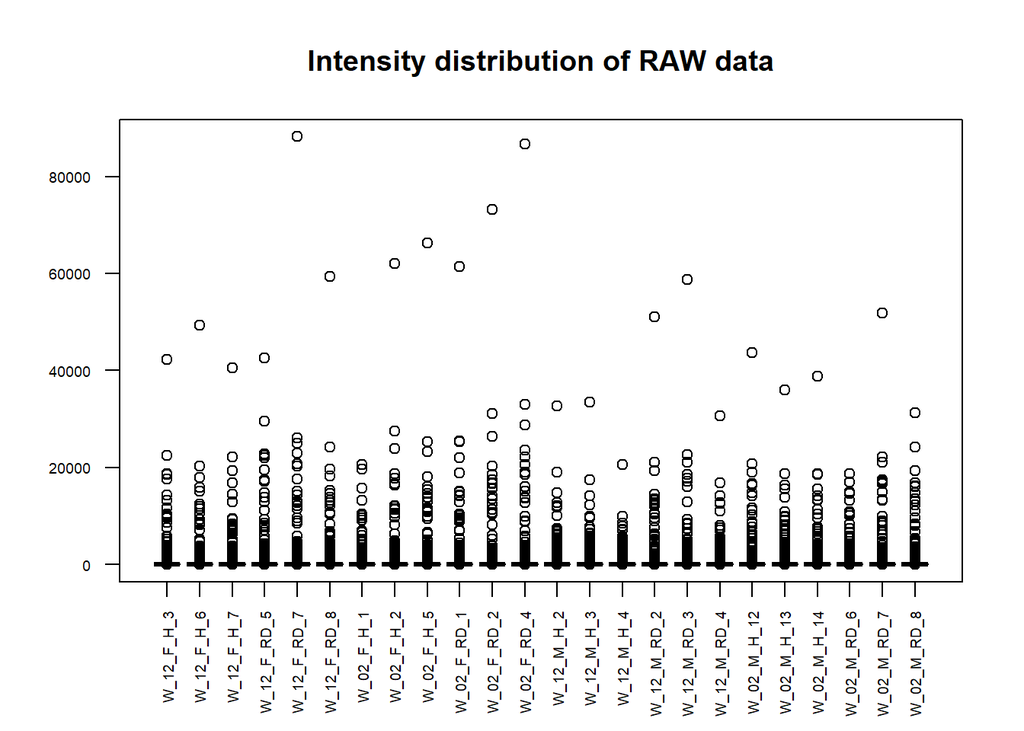

```r
boxplot(df_tpm[,-1], which="all",las=2, main="Intensity distribution of RAW data",
        cex.axis=0.6, col=as.factor(metadata$Diet), names=metadata$`Short code`)
```

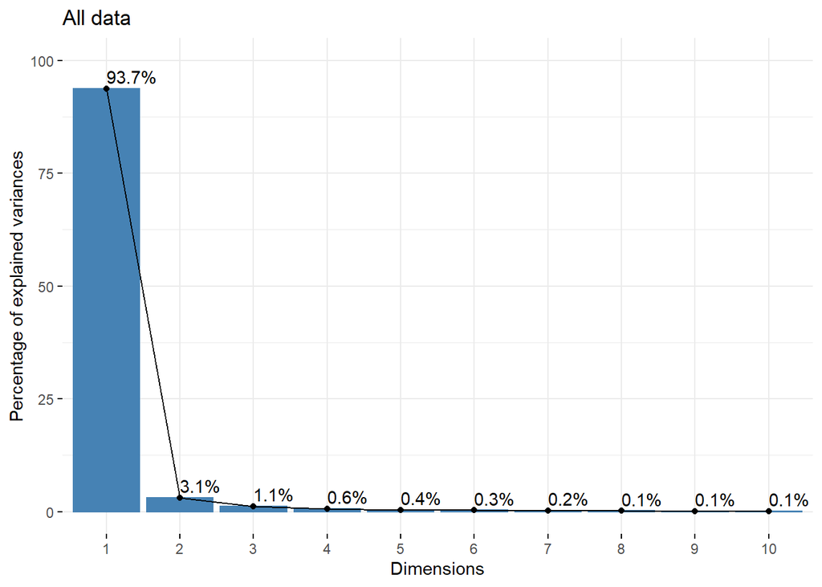

```r
#pcX<-prcomp(df_tpm[,-1]) # o prcomp(t(X))
#loads<- round(pcX$sdev^2/sum(pcX$sdev^2)*100,1)
#xlab<-c(paste("PC1",loads[1],"%"))
#ylab<-c(paste("PC2",loads[2],"%"))
#plot(pcX$rotation[,1:2],xlab=xlab,ylab=ylab, col=as.factor(metadata$Diet),
#       xlim=c(min(pcX$rotation[,1])-100000, max(pcX$x[,1])+100000),ylim=c(min(pcX$x[,2])-100000, max(pcX$x[,2])+100000))
#text(pcX$rotation[,1],pcX$rotation[,2], pos=3)
#title(paste("Plot of first 2 PCs", sep=" "), cex=0.8)

library("FactoMineR")
library("factoextra")
#pdf(file = "PCA mapping_factominer and factoextra.pdf")
res.pca <- PCA(df_tpm[,-1], scale.unit = FALSE, ncp = 10, graph = FALSE)
fviz_eig(res.pca, addlabels = TRUE, ylim = c(0, 100),main = "All data") # The scree plot suggests PC-1 and PC-2 are the best options.
```

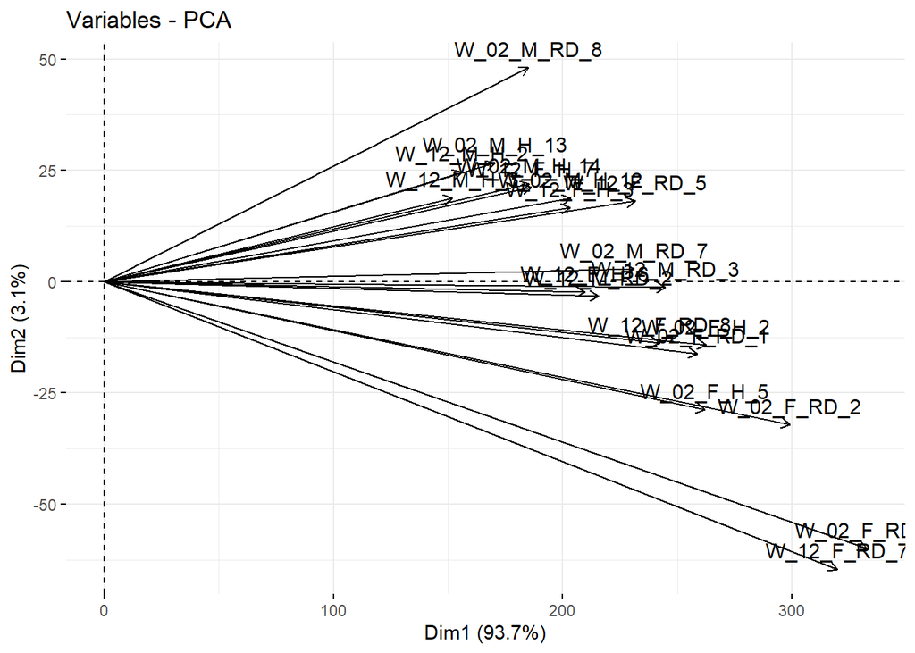

```r
fviz_pca_var(res.pca, axes = c(1, 2), geom = c("arrow", "text"),repel = FALSE,
             col.var = "black", fill.var = "white",alpha.var = 1, col.quanti.sup = "blue",
             col.circle = "grey70",select.var = list(cos2 = 20))
```

[figure not shown]

```r
# Chow diet: despite the data is a bit disperse (despite ewat05 is not close to the rest, it's not clearly an outlier), I can observe clusters.
complete_df <- as.data.frame(res.pca$var$coord[,1:2])
complete_df$`Short code` <- rownames(complete_df)
complete_df <- left_join(complete_df, metadata, by = "Short code")
rownames(complete_df) <- complete_df$`Short code`
ggplot(complete_df, aes(Dim.1, Dim.2, color = Diet)) + geom_point() + theme_classic()+ geom_text_repel(aes(group = Time, label = paste(" ",rownames(complete_df))), hjust = "left", size = 3)+ ggtitle("PCA analysis\nBefore batch correction") + xlab("PC-1 (93.7%)") + ylab("PC-2 (4.1%)")+theme_classic()
```

[figure not shown]

```r
ggplot(complete_df, aes(Dim.1, Dim.2, color = Time)) + geom_point() + theme_classic()+ geom_text_repel(aes(group = Time, label = paste(" ",rownames(complete_df))), hjust = "left", size = 3)+ ggtitle("PCA analysis\nBefore batch correction") + xlab("PC-1 (93.7%)") + ylab("PC-2 (4.1%)")+theme_classic()
```

[figure not shown]

```r
ggplot(complete_df, aes(Dim.1, Dim.2, color = Sex)) + geom_point() + theme_classic()+ geom_text_repel(aes(group = Time, label = paste(" ",rownames(complete_df))), hjust = "left", size = 3)+ ggtitle("PCA analysis\nBefore batch correction") + xlab("PC-1 (93.7%)") + ylab("PC-2 (4.1%)")+theme_classic()
```

```r
#dev.off()
```

Another way to study the data distribution is MDS, similar to PCA, in “magrittr” and “ggpubr” packages: in this case the groups clearly cluster well associated to Diet. However, this calculation does not provide the percentage value.

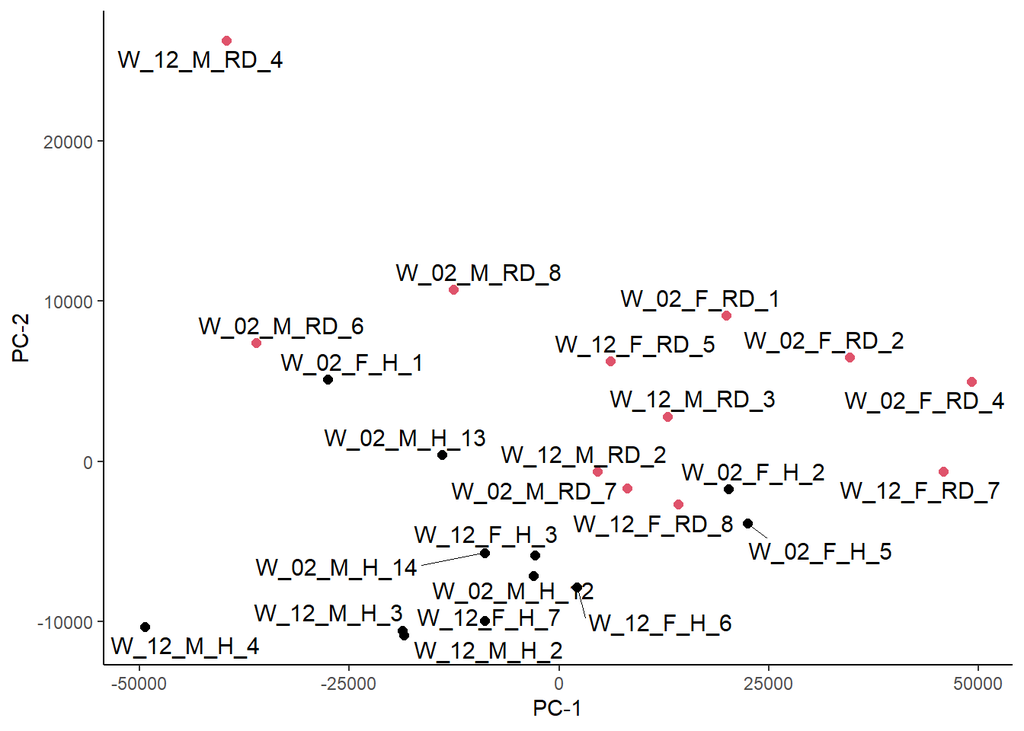

```r
mds_cd <- t(df_tpm[,-1]) %>%
  dist() %>% cmdscale() %>% as_tibble()
colnames(mds_cd) <- c("Dim.1", "Dim.2")
ggscatter(mds_cd, x = "Dim.1", y = "Dim.2", label = colnames(df_tpm[,-1]),
          size = 2, color = if_else(complete_df$Diet == "HFD",1,2),repel = TRUE)+ xlab("PC-1") + ylab("PC-2")+theme_classic()
```

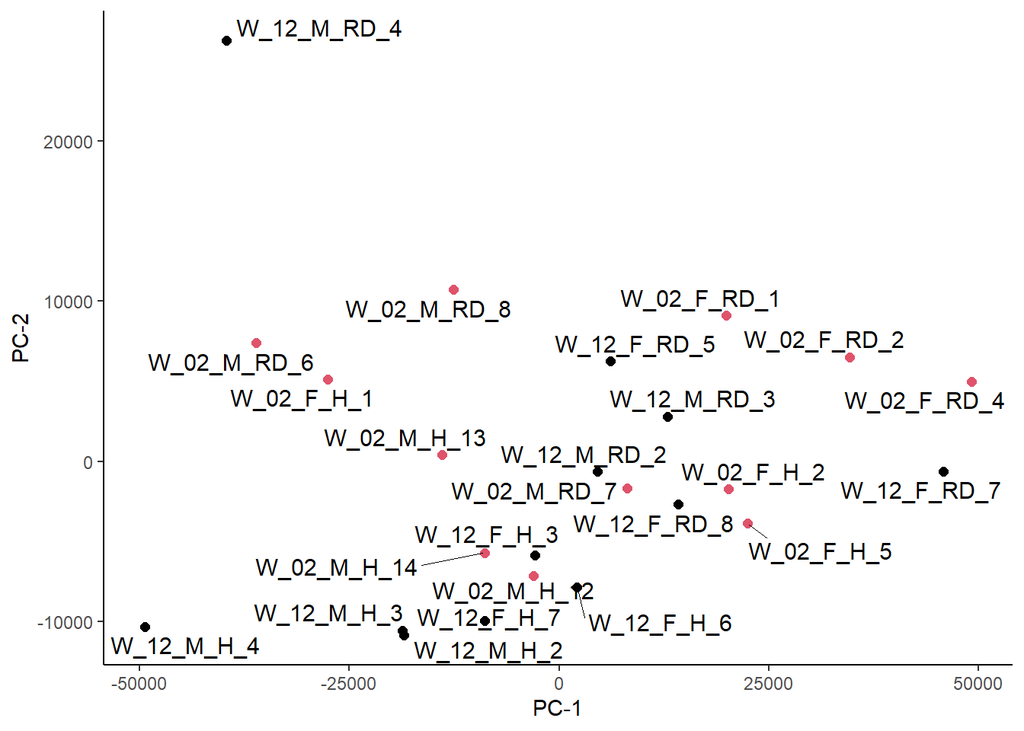

```r
ggscatter(mds_cd, x = "Dim.1", y = "Dim.2", label = colnames(df_tpm[,-1]),
          size = 2, color = if_else(complete_df$Time == "12WK",1,2),repel = TRUE)+ xlab("PC-1") + ylab("PC-2")+theme_classic()
```

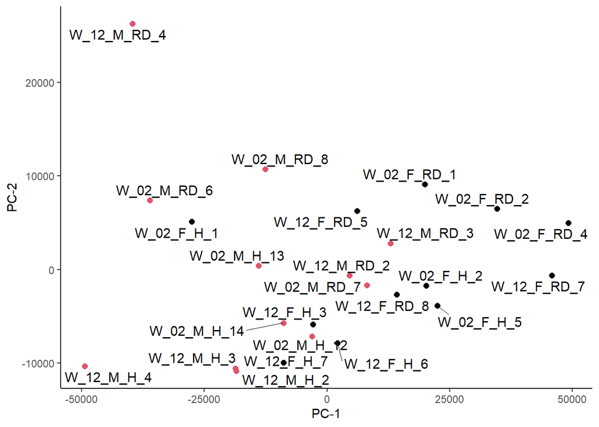

```r
ggscatter(mds_cd, x = "Dim.1", y = "Dim.2", label = colnames(df_tpm[,-1]),
          size = 2, color = if_else(complete_df$Sex == "F",1,2),repel = TRUE)+ xlab("PC-1") + ylab("PC-2")+theme_classic()
```

The distance matrix suggested it’s convenient to run a batch correction.

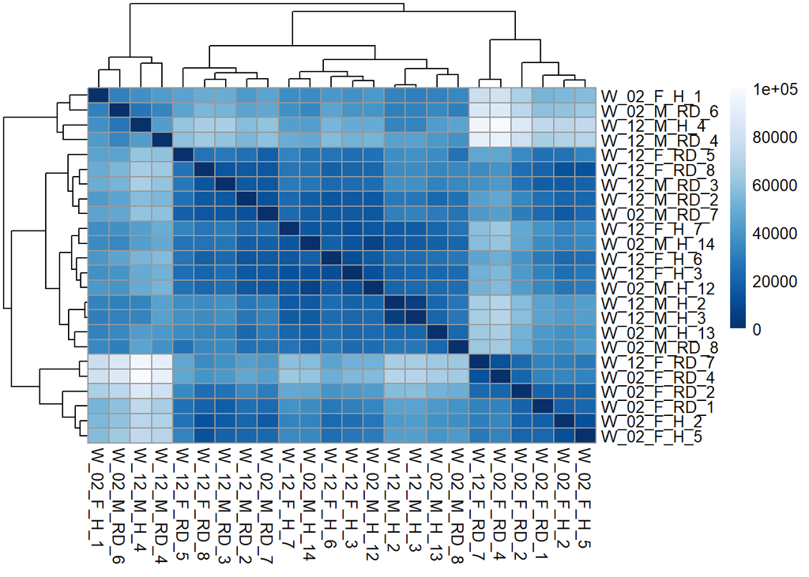

```r
library("pheatmap")
library("RColorBrewer")
library("DESeq2")
colors <- colorRampPalette(rev(brewer.pal(9, "Blues")))(255)
sampleDists <- dist(t((as.matrix(df_tpm[,-1]))))
sampleDistMatrix <- as.matrix(sampleDists)
pheatmap(sampleDistMatrix, col=colors)
```

# 5. Illumina threshold and batch correction

## 5.1 Illumina

Mail from Jordi Altirriba to Marc the 12th of September, 2020, suggested filtrating counts: << *(…)* *Respecte els threshold, el que diu Illumina és que un transcrit com a mínim ha de tenir 10 counts (no CPMs) per considerar-se present. Això en CPMs és entre 0.1 i 1 CPM, depenent del nombre de reads obtinguts.* *No hi ha un criteri únic de filtratge, al igual que no ho havia en els microarrays. En els primer microarrays hi havia una doble seqüència per trànscrit, una que feia perfect match i l’altre amb un canvi de base (mismatch), a partir dels valors es podia calcular si el gen estava present o absent (Mol Metab del 2013). Els microarrays posteriors, per abaratir costos i tenint en compte que el RMA no utilitzava la seqüència MisMatch (MM) es varen eliminar i varem començar a utilitzar thresholds d’expressió.* *En el RNASeq no hi ha un criteri únic i pot dependre del disseny experimental. No serà el mateix tenim 20 milions de reads que 60, ni treballar amb un cultiu cel·lular que amb single cells. Com a mínim, s’ha de fer un tall de 1 CPM (o FPKM). El fet de pujar el tall, farà que estiguis més segur de poder reproduir els resultats.* *Jo el que faig a les taules és analitzar totes les dades amb un tall de 10 counts (no CPMs) i faig la taula inicial del Excel (la de l’esquerra del tot a les Tabs) i després faig una selecció dels gens per FDR, FC i CPMs.* *Així, sempre es pot anar a veure a la taula inicial els gens que volguessis consultar.* *Hi han alguns estadístics que consideren que no s’hauria de fer tall per CPMs ni per Fold Change, si no únicament per FDR. Però tots sabem que si el gen s’expressa mooolt poc o el fold change és moooolt petit, costa mooooolt després en reproduir aquell resultat. Així, busquem resultats robustus que després ens el podem creure i poguem posteriorment construir sobre els resultats obtinguts. A vegades, aquests tipus de tècniques es consideren random machines number generators, ja que crea molts números i alguns són significatius per atzar (sempre tenim aquest 0.05 o 5% d’error). Així, augmentem la robustesa de les dades ficant altres thresholds.* *Així, per exemple a Ginebra fan un threshold de 1 FPKM i un fold change de 2.* *Altres exemples:* *Sterson 2015: per trobar els DEG, CPM>1, per filtrar les llistes , FDR<0.05, FC>2, CPM>20)* *El EdgeR recomana fer un filtratge a 0.5CPM* *Aquí parlen d’una RPKM d’entre 1 i 10: https://www.ncbi.nlm.nih.gov/pmc/articles/PMC6096346/* *Hi han algunes eines per determinar-ho.* *Lo ideal seria saber si algún gen específic que estigui poc expressat està o no en el teu sistema.*

*Realment pots anar a una CPM o FPKM d’1 en canvi de pujar a 20.* *(…)*>>

Thus, we have agreed I will apply here a filtration of 10 reads and later, in the Excel table, I will explore other filtrations (to begin with: 1.5 FC, and *p-value* < 0.05). I select the rows of numReads > 10 reads to keep the more highly expressed genes. With this filtration,, we have passed from a constant list of genes of 116357 genes, to a variable range of 50000 genes.

```r
h12f3s9 <- WAT_HFD_12WK_F_3_S9_salmon[WAT_HFD_12WK_F_3_S9_salmon$NumReads > 10,c(1,4)]
h12f6s10 <- WAT_HFD_12WK_F_6_S10_salmon[WAT_HFD_12WK_F_6_S10_salmon$NumReads > 10,c(1,4)]
h12f7s11 <- WAT_HFD_12WK_F_7_S11_salmon[WAT_HFD_12WK_F_7_S11_salmon$NumReads > 10,c(1,4)]
rd12f5s12 <- WAT_RD_12WK_F_5_S12_salmon[WAT_RD_12WK_F_5_S12_salmon$NumReads > 10,c(1,4)]
rd12f7s13 <- WAT_RD_12WK_F_7_S13_salmon[WAT_RD_12WK_F_7_S13_salmon$NumReads > 10,c(1,4)]
rd12f8s14 <- WAT_RD_12WK_F_8_S14_salmon[WAT_RD_12WK_F_8_S14_salmon$NumReads > 10,c(1,4)]
h2f1s15 <- WAT_HFD_2WK_F_1_S15_salmon[WAT_HFD_2WK_F_1_S15_salmon$NumReads > 10,c(1,4)]
h2f2s16 <- WAT_HFD_2WK_F_2_S16_salmon[WAT_HFD_2WK_F_2_S16_salmon$NumReads > 10,c(1,4)]
h2f5s1 <- WAT_HFD_2WK_F_5_S1_salmon[WAT_HFD_2WK_F_5_S1_salmon$NumReads > 10,c(1,4)]
rd2f1s2 <- WAT_RD_2WK_F_1_S2_salmon[WAT_RD_2WK_F_1_S2_salmon$NumReads > 10,c(1,4)]
rd2f2s3 <- WAT_RD_2WK_F_2_S3_salmon[WAT_RD_2WK_F_2_S3_salmon$NumReads > 10,c(1,4)]
rd2f4s4 <- WAT_RD_2WK_F_4_S4_salmon[WAT_RD_2WK_F_4_S4_salmon$NumReads > 10,c(1,4)]
h12m2s5 <- WAT_HFD_12WK_M_2_S5_salmon[WAT_HFD_12WK_M_2_S5_salmon$NumReads > 10,c(1,4)]
h12m3s6 <- WAT_HFD_12WK_M_3_S6_salmon[WAT_HFD_12WK_M_3_S6_salmon$NumReads > 10,c(1,4)]
h12m4s7 <- WAT_HFD_12WK_M_4_S7_salmon[WAT_HFD_12WK_M_4_S7_salmon$NumReads > 10,c(1,4)]
rd12m2s8 <- WAT_RD_12WK_M_2_S8_salmon[WAT_RD_12WK_M_2_S8_salmon$NumReads > 10,c(1,4)]
rd12m3s9 <- WAT_RD_12WK_M_3_S9_salmon[WAT_RD_12WK_M_3_S9_salmon$NumReads > 10,c(1,4)]
rd12m4s10 <- WAT_RD_12WK_M_4_S10_salmon[WAT_RD_12WK_M_4_S10_salmon$NumReads > 10,c(1,4)]
h2m12s11 <- WAT_HFD_2WK_M_12_S11_salmon[WAT_HFD_2WK_M_12_S11_salmon$NumReads > 10,c(1,4)]
h2m13s12 <- WAT_HFD_2WK_M_13_S12_salmon[WAT_HFD_2WK_M_13_S12_salmon$NumReads > 10,c(1,4)]
h2m14s13 <- WAT_HFD_2WK_M_14_S13_salmon[WAT_HFD_2WK_M_14_S13_salmon$NumReads > 10,c(1,4)]
rd2m6s14 <- WAT_RD_2WK_M_6_S14_salmon[WAT_RD_2WK_M_6_S14_salmon$NumReads > 10,c(1,4)]
rd2m7s15 <- WAT_RD_2WK_M_7_S15_salmon[WAT_RD_2WK_M_7_S15_salmon$NumReads > 10,c(1,4)]
rd2m8s16 <- WAT_RD_2WK_M_8_S16_salmon[WAT_RD_2WK_M_8_S16_salmon$NumReads > 10,c(1,4)]
```

I filtrate the metadata to obtain the wat samples, and discard the file name columns:

```r
metadata <- Samples_code_HFD_MF_2_12wk[Samples_code_HFD_MF_2_12wk$Tissue == "WAT",1:11]
rownames(metadata) <- metadata$`Short code`
```

In order to get an association between the metadata table and the TPMs table, I name the TPMs column with the “Short code” name before joining the TPMs tables according to the gene’s name column:

```r
colnames(h12f3s9)[2] <- 'W_12_F_H_3'
colnames(h12f6s10)[2] <- 'W_12_F_H_6'
colnames(h12f7s11)[2] <- 'W_12_F_H_7'
colnames(rd12f5s12)[2] <- 'W_12_F_RD_5'
colnames(rd12f7s13)[2] <- 'W_12_F_RD_7'
colnames(rd12f8s14)[2] <- 'W_12_F_RD_8'
colnames(h2f1s15)[2] <- 'W_02_F_H_1'
colnames(h2f2s16)[2] <- 'W_02_F_H_2'
colnames(h2f5s1)[2] <- 'W_02_F_H_5'
colnames(rd2f1s2)[2] <- 'W_02_F_RD_1'
colnames(rd2f2s3)[2] <- 'W_02_F_RD_2'
colnames(rd2f4s4)[2] <- 'W_02_F_RD_4'
colnames(h12m2s5)[2] <- 'W_12_M_H_2'
colnames(h12m3s6)[2] <- 'W_12_M_H_3'
colnames(h12m4s7)[2] <- 'W_12_M_H_4'
colnames(rd12m2s8)[2] <- 'W_12_M_RD_2'
colnames(rd12m3s9)[2] <- 'W_12_M_RD_3'
colnames(rd12m4s10)[2] <- 'W_12_M_RD_4'
colnames(h2m12s11)[2] <-'W_02_M_H_12'
colnames(h2m13s12)[2] <- 'W_02_M_H_13'
colnames(h2m14s13)[2] <- 'W_02_M_H_14'
colnames(rd2m6s14)[2] <- 'W_02_M_RD_6'
colnames(rd2m7s15)[2] <- 'W_02_M_RD_7'
colnames(rd2m8s16)[2] <- 'W_02_M_RD_8'
```

At this point, I can join the different TMP tables by the “Name” column. This way, all the counts will be in the same row of the corresponding transcript.

```r
df1 <- left_join(h12f3s9,h12f6s10, by = "Name")
df2 <- left_join(df1,h12f7s11, by = "Name")
df3 <- left_join(df2,rd12f5s12, by = "Name")
df4 <- left_join(df3, rd12f7s13, by = "Name")
df5 <- left_join(df4, rd12f8s14, by = "Name")
df6 <- left_join(df5, h2f1s15, by = "Name")
df7 <- left_join(df6, h2f2s16, by = "Name")
df8 <- left_join(df7, h2f5s1, by = "Name")
df9 <- left_join(df8, rd2f1s2, by = "Name")
df10 <- left_join(df9, rd2f2s3, by = "Name")
df11 <- left_join(df10, rd2f4s4, by = "Name")
df12 <- left_join(df11, h12m2s5, by = "Name")
df13 <- left_join(df12, h12m3s6, by = "Name")
df14 <- left_join(df13, h12m4s7, by = "Name")
df15 <- left_join(df14, rd12m2s8, by = "Name")
df16 <- left_join(df15, rd12m3s9, by = "Name")
df17 <- left_join(df16, rd12m4s10, by = "Name")
df18 <- left_join(df17, h2m12s11, by = "Name")
df19 <- left_join(df18, h2m13s12, by = "Name")
df20 <- left_join(df19, h2m14s13, by = "Name")
df21 <- left_join(df20, rd2m6s14, by = "Name")
df22 <- left_join(df21, rd2m7s15, by = "Name")
df_tpm2 <- left_join(df22, rd2m8s16, by = "Name")
rownames(df_tpm2) <- df_tpm2$Name
rm(df1, df2, df3, df4, df5, df6, df7, df8, df9, df10, df11, df12, df13, df14, df15, df16, df17, df18, df19, df20, df21, df22)
```

The final working table has some `NA` values. Thus, I need to remove them: the working table has now about 32000 genes.

```r
df_tpm2$SUMA <- apply(df_tpm2[,-1],1, mean)
df_tpm2 <- df_tpm2[-which(is.na(df_tpm2$SUMA)==TRUE),]
df_tpm2 <- df_tpm2[,-ncol(df_tpm2)]
dim(df_tpm2) #  32730    25
```

```
## [1] 32730    25
```

## 5.2 Batch correction

I calculate the correction of batch effect (limma R package):

```r
rownames(df_tpm2) <- df_tpm2$Name
mat <- limma::removeBatchEffect(df_tpm2[,-1], metadata$Batch)
rownames(mat) <- df_tpm2$Name
kable(round(mat[1:4,1:4],3), caption = "Section of the TPM table:")
```

Section of the TPM table:

|  | W_12_F_H_3 | W_12_F_H_6 | W_12_F_H_7 | W_12_F_RD_5 |
| --- | --- | --- | --- | --- |
| ENSMUST00000103679.3 | 1.417 | 2.491 | 2.085 | 2.477 |
| ENSMUST00000192856.6 | 2.643 | 5.434 | 6.541 | 2.978 |
| ENSMUST00000103299.3 | 8.153 | 8.839 | 7.559 | 6.944 |
| ENSMUST00000196323.2 | 0.432 | 1.045 | 0.340 | 0.471 |

```r
write.table(mat, "Normalized_reads_as_TPMs_and_Jordi.txt", sep = "\t", dec = ".", row.names = T)
```

Data exploration after batch correction:

- Boxplot and PCA.

[figure not shown]

```r
boxplot(mat, which="all",las=2, main="Intensity distribution of RAW data",
        cex.axis=0.6, col=as.factor(metadata$Diet), names=metadata$`Short code`)
```

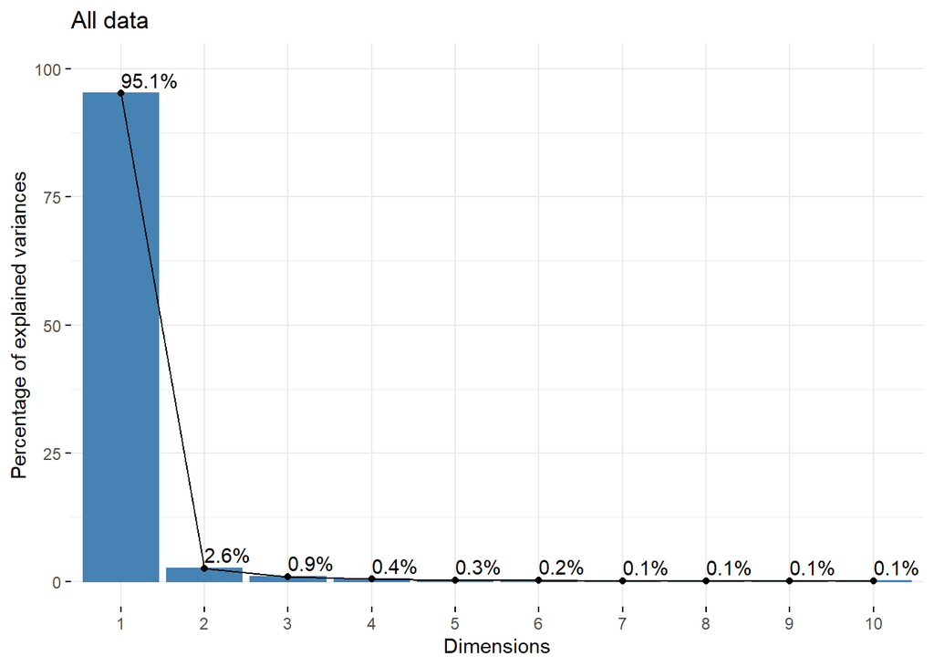

```r
library("FactoMineR")
library("factoextra")
#pdf(file = "PCA mapping_factominer and factoextra.pdf")
res.pca <- PCA(mat, scale.unit = FALSE, ncp = 10, graph = FALSE)
fviz_eig(res.pca, addlabels = TRUE, ylim = c(0, 100),main = "All data") # The scree plot suggests PC-1 and PC-2 are the best options.
```

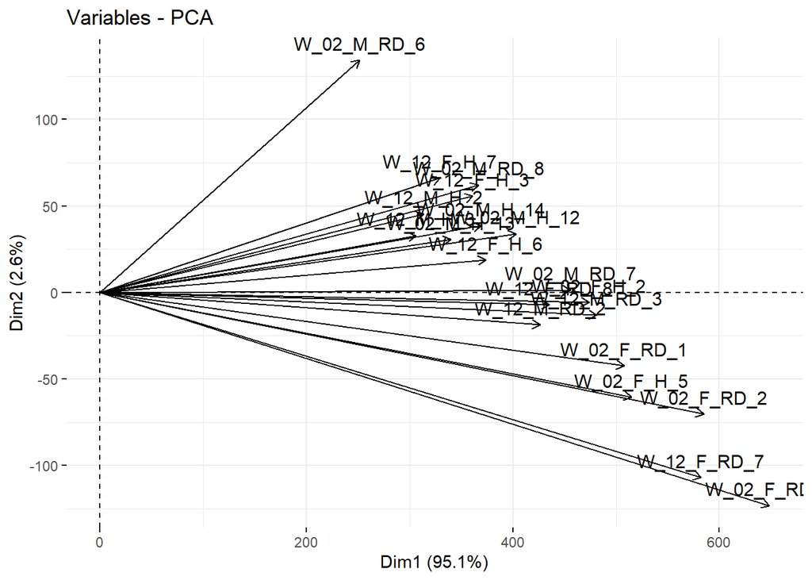

```r
fviz_pca_var(res.pca, axes = c(1, 2), geom = c("arrow", "text"),repel = FALSE,
             col.var = "black", fill.var = "white",alpha.var = 1, col.quanti.sup = "blue",
             col.circle = "grey70",select.var = list(cos2 = 20))
```

[figure not shown]

```r
# Chow diet: despite the data is a bit disperse (despite ewat05 is not close to the rest, it's not clearly an outlier), I can observe clusters.
complete_df <- as.data.frame(res.pca$var$coord[,1:2])
complete_df$`Short code` <- rownames(complete_df)
complete_df <- left_join(complete_df, metadata, by = "Short code")
rownames(complete_df) <- complete_df$`Short code`
ggplot(complete_df, aes(Dim.1, Dim.2, color = Diet)) + geom_point() + theme_classic()+ geom_text_repel(aes(group = Time, label = paste(" ",rownames(complete_df))), hjust = "left", size = 3)+ ggtitle("PCA analysis\nBefore batch correction") + xlab("PC-1 (93.7%)") + ylab("PC-2 (4.1%)")+theme_classic()
```

[figure not shown]

```r
ggplot(complete_df, aes(Dim.1, Dim.2, color = Time)) + geom_point() + theme_classic()+ geom_text_repel(aes(group = Time, label = paste(" ",rownames(complete_df))), hjust = "left", size = 3)+ ggtitle("PCA analysis\nBefore batch correction") + xlab("PC-1 (93.7%)") + ylab("PC-2 (4.1%)")+theme_classic()
```

[figure not shown]

```r
ggplot(complete_df, aes(Dim.1, Dim.2, color = Sex)) + geom_point() + theme_classic()+ geom_text_repel(aes(group = Time, label = paste(" ",rownames(complete_df))), hjust = "left", size = 3)+ ggtitle("PCA analysis\nBefore batch correction") + xlab("PC-1 (93.7%)") + ylab("PC-2 (4.1%)")+theme_classic()
```

```r
#dev.off()
```

Another way to study the data distribution is MDS, similar to PCA, in “magrittr” and “ggpubr” packages: in this case the groups clearly cluster well associated to Diet. However, this calculation does not provide the percentage value.

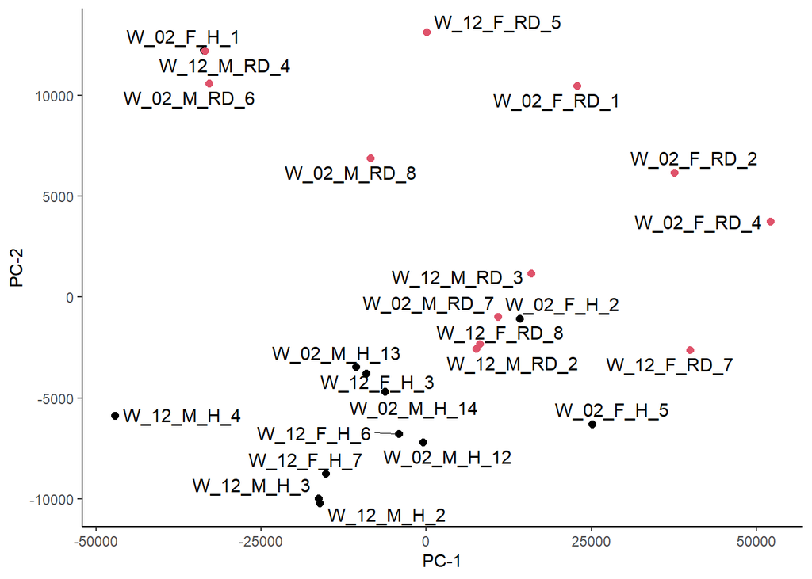

```r
mds_cd <- t(mat) %>%
  dist() %>% cmdscale() %>% as_tibble()
colnames(mds_cd) <- c("Dim.1", "Dim.2")
ggscatter(mds_cd, x = "Dim.1", y = "Dim.2", label = colnames(mat),
          size = 2, color = if_else(complete_df$Diet == "HFD",1,2),repel = TRUE)+ xlab("PC-1") + ylab("PC-2")+theme_classic()
```

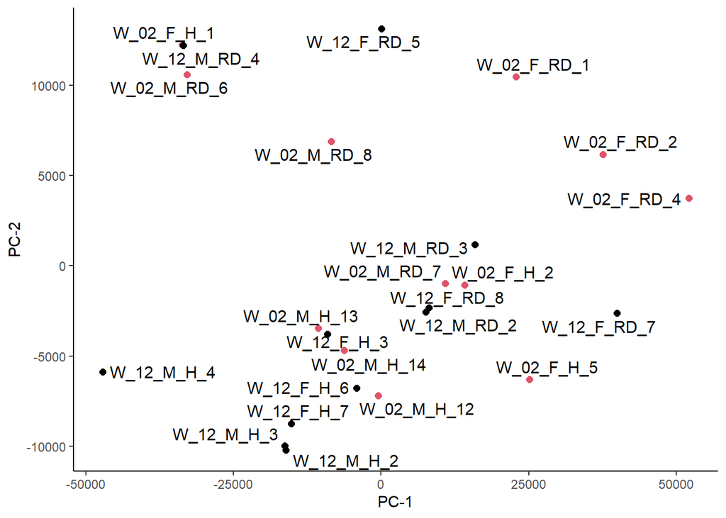

```r
ggscatter(mds_cd, x = "Dim.1", y = "Dim.2", label = colnames(mat),
          size = 2, color = if_else(complete_df$Time == "12WK",1,2),repel = TRUE)+ xlab("PC-1") + ylab("PC-2")+theme_classic()
```

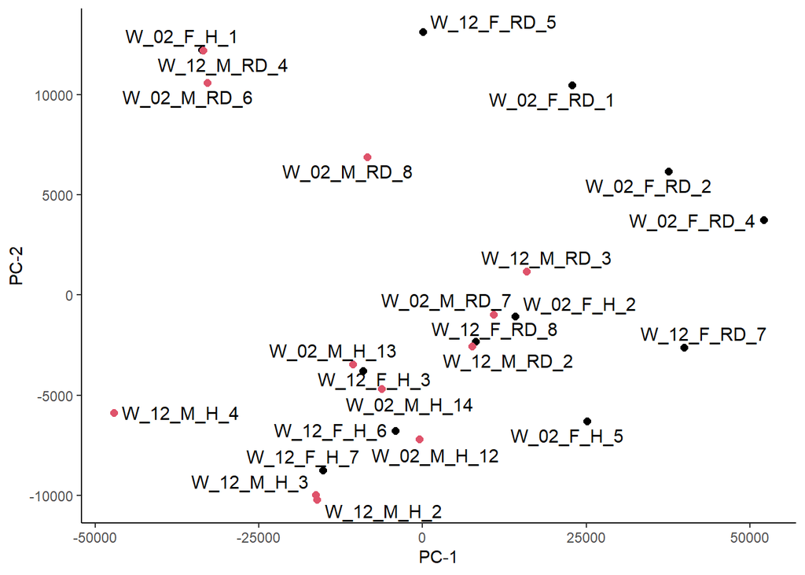

```r
ggscatter(mds_cd, x = "Dim.1", y = "Dim.2", label = colnames(mat),
          size = 2, color = if_else(complete_df$Sex == "F",1,2),repel = TRUE)+ xlab("PC-1") + ylab("PC-2")+theme_classic()
```

The distance matrix suggested it’s convenient to filtrate genes according to biological criteria.

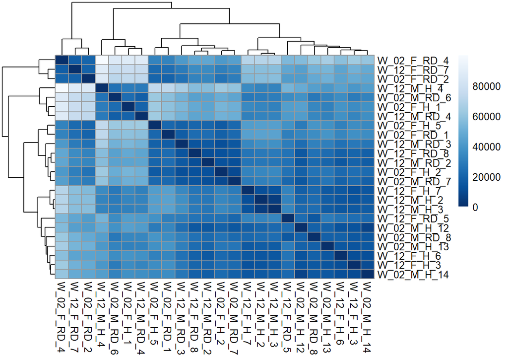

```r
library("pheatmap")
library("RColorBrewer")
library("DESeq2")

colors <- colorRampPalette(rev(brewer.pal(9, "Blues")))(255)
sampleDists <- dist(t((as.matrix(mat))))
sampleDistMatrix <- as.matrix(sampleDists)
pheatmap(sampleDistMatrix, col=colors)
```